# Practical machine learning course project

Amirhossein vahidi

5/21/2020

This document is my project for the Coursera course Practical machine learning. In this project, we use data from accelerometers on the belt, forearm, arm, and dumbell of 6 participants to predict how they did the exercise.  
Executive summary In this projecct, we have 19622 observations for over 180 features. First, the variability of different features is evaluated to find essential features. Then, the features are preprocessed. The k fold cross-validation is used for cross-validation. And random forest algorithm is used for modelling with accuracy over 97 percent. After importing data, zero covariants are removed with function nsv.

```r
library(caret)
library("readxl")
training = read.csv("C:\\Users\\vh\\Desktop\\pml-training.csv")
testing = read.csv("C:\\Users\\vh\\Desktop\\pml-testing.csv")
nsv <- nearZeroVar(training,saveMetrics = FALSE)
training <- training[,-nsv]
testing <- testing[,-nsv]
training$cvtd_timestamp <- as.numeric(training$cvtd_timestamp)
testing$cvtd_timestamp <- as.numeric(testing$cvtd_timestamp)
training <- training[,2:100]
testing <- testing[,2:100]
summary(training)
```

```
##     user_name    raw_timestamp_part_1 raw_timestamp_part_2 cvtd_timestamp
##  adelmo  :3892   Min.   :1.322e+09    Min.   :   294       Min.   : 1.00
##  carlitos:3112   1st Qu.:1.323e+09    1st Qu.:252912       1st Qu.: 6.00
##  charles :3536   Median :1.323e+09    Median :496380       Median :11.00
##  eurico  :3070   Mean   :1.323e+09    Mean   :500656       Mean   :10.98
##  jeremy  :3402   3rd Qu.:1.323e+09    3rd Qu.:751891       3rd Qu.:16.00
##  pedro   :2610   Max.   :1.323e+09    Max.   :998801       Max.   :20.00
##
##    num_window      roll_belt        pitch_belt          yaw_belt
##  Min.   :  1.0   Min.   :-28.90   Min.   :-55.8000   Min.   :-180.00
##  1st Qu.:222.0   1st Qu.:  1.10   1st Qu.:  1.7600   1st Qu.: -88.30
##  Median :424.0   Median :113.00   Median :  5.2800   Median : -13.00
##  Mean   :430.6   Mean   : 64.41   Mean   :  0.3053   Mean   : -11.21
##  3rd Qu.:644.0   3rd Qu.:123.00   3rd Qu.: 14.9000   3rd Qu.:  12.90
##  Max.   :864.0   Max.   :162.00   Max.   : 60.3000   Max.   : 179.00
##
##  total_accel_belt max_roll_belt     max_picth_belt  min_roll_belt
##  Min.   : 0.00    Min.   :-94.300   Min.   : 3.00   Min.   :-180.00
##  1st Qu.: 3.00    1st Qu.:-88.000   1st Qu.: 5.00   1st Qu.: -88.40
##  Median :17.00    Median : -5.100   Median :18.00   Median :  -7.85
##  Mean   :11.31    Mean   : -6.667   Mean   :12.92   Mean   : -10.44
##  3rd Qu.:18.00    3rd Qu.: 18.500   3rd Qu.:19.00   3rd Qu.:   9.05
##  Max.   :29.00    Max.   :180.000   Max.   :30.00   Max.   : 173.00
##                   NA's   :19216     NA's   :19216   NA's   :19216
##  min_pitch_belt  amplitude_roll_belt amplitude_pitch_belt var_total_accel_belt
##  Min.   : 0.00   Min.   :  0.000     Min.   : 0.000       Min.   : 0.000
##  1st Qu.: 3.00   1st Qu.:  0.300     1st Qu.: 1.000       1st Qu.: 0.100
##  Median :16.00   Median :  1.000     Median : 1.000       Median : 0.200
##  Mean   :10.76   Mean   :  3.769     Mean   : 2.167       Mean   : 0.926
##  3rd Qu.:17.00   3rd Qu.:  2.083     3rd Qu.: 2.000       3rd Qu.: 0.300
##  Max.   :23.00   Max.   :360.000     Max.   :12.000       Max.   :16.500
##  NA's   :19216   NA's   :19216       NA's   :19216        NA's   :19216
##  avg_roll_belt    stddev_roll_belt var_roll_belt     avg_pitch_belt
##  Min.   :-27.40   Min.   : 0.000   Min.   :  0.000   Min.   :-51.400
##  1st Qu.:  1.10   1st Qu.: 0.200   1st Qu.:  0.000   1st Qu.:  2.025
##  Median :116.35   Median : 0.400   Median :  0.100   Median :  5.200
##  Mean   : 68.06   Mean   : 1.337   Mean   :  7.699   Mean   :  0.520
##  3rd Qu.:123.38   3rd Qu.: 0.700   3rd Qu.:  0.500   3rd Qu.: 15.775
##  Max.   :157.40   Max.   :14.200   Max.   :200.700   Max.   : 59.700
##  NA's   :19216    NA's   :19216    NA's   :19216     NA's   :19216
```

[output cut: 153 more lines]

```
##  Min.   :-632.0   Min.   :-446.00   Min.   :-1280.0   Min.   :-896.0
##  1st Qu.:  57.0   1st Qu.:-182.00   1st Qu.: -616.0   1st Qu.:   2.0
##  Median : 201.0   Median : -39.00   Median : -378.0   Median : 591.0
##  Mean   : 163.7   Mean   : -55.29   Mean   : -312.6   Mean   : 380.1
##  3rd Qu.: 312.0   3rd Qu.:  26.00   3rd Qu.:  -73.0   3rd Qu.: 737.0
##  Max.   : 923.0   Max.   : 291.00   Max.   :  672.0   Max.   :1480.0
##
##  magnet_forearm_z classe
##  Min.   :-973.0   A:5580
##  1st Qu.: 191.0   B:3797
##  Median : 511.0   C:3422
##  Mean   : 393.6   D:3216
##  3rd Qu.: 653.0   E:3607
##  Max.   :1090.0
##
```

As you can see in the summary of data, some of the features have too many NA values. Some of the features are highly correlated. Features that are correlated are in the following:

```r
cr<-cor(training[,2:98])
diag(cr)<-NA
c<-which(cr>0.7,arr.ind = T)
corr<-unique(c[,2])
corr
```

```
##  [1]  3  5  7  8 25 28 29 30 31 32 33 42 43 44 45 46 47 52 53 54 61 74 75 76 77
## [26] 79 90 91 93 96
```

To have better and fewer features and also solve the problem of too many NA values for some features, data are preprocessed with two method PCA and bagImpute for features with NA value. So the numbers of features are twenty now. After preprocessing, ten-fold cross-validation is used in train control function. The random forest algorithm has better accuracy than the tree algorithm, and also it is better for classification prediction. The final accuracy is over 0.97 percent.

```r
pre<-preProcess(training[,-99],
                 method = c("pca","bagImpute"),
                 pcaComp = 20
                 )
trainpc<-predict(pre,training[,-99])
trainpc <- cbind(trainpc,classe = training$classe)
set.seed(1)
train.control <- trainControl(method="cv", number = 10)
fit<- train(classe~., method = "rf",data=trainpc,trControl = train.control)
print(fit)
```

```
## Random Forest
##
## 19622 samples
##    21 predictor
##     5 classes: 'A', 'B', 'C', 'D', 'E'
##
## No pre-processing
## Resampling: Cross-Validated (10 fold)
## Summary of sample sizes: 17658, 17660, 17660, 17660, 17659, 17661, ...
## Resampling results across tuning parameters:
##
##   mtry  Accuracy   Kappa
##    2    0.9701350  0.9622185
##   13    0.9717145  0.9642141
##   25    0.9664147  0.9575117
##
## Accuracy was used to select the optimal model using the largest value.
## The final value used for the model was mtry = 13.
```

The optimizzed tuning parameters (mtry) is 13

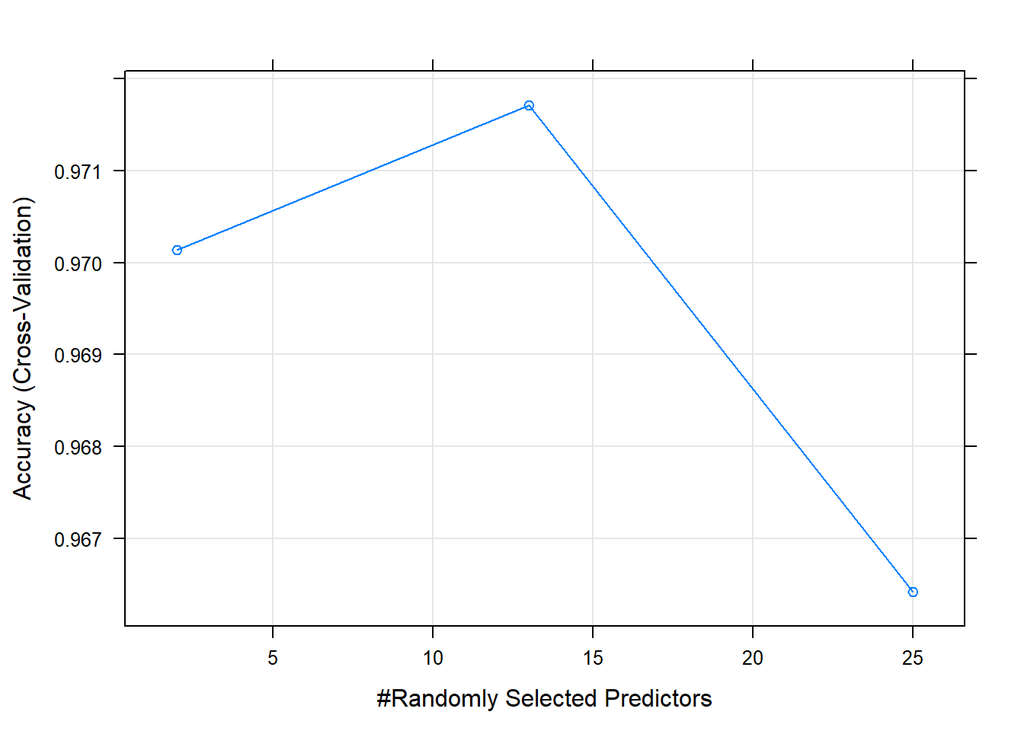

```r
plot(fit)
```

The out of sample error is around 2.5 percent.

```r
fit$finalModel
```

```
##
## Call:
##  randomForest(x = x, y = y, mtry = param$mtry)
##                Type of random forest: classification
##                      Number of trees: 500
## No. of variables tried at each split: 13
##
##         OOB estimate of  error rate: 2.63%
## Confusion matrix:
##      A    B    C    D    E class.error
## A 5493   27   37   18    5  0.01559140
## B   84 3642   53    2   16  0.04082170
## C   27   38 3323   27    7  0.02893045
## D   20   10   79 3098    9  0.03669154
## E    4   16   18   19 3550  0.01580261
```

After using preprocess results to modify the test data, Class for test is predicted.

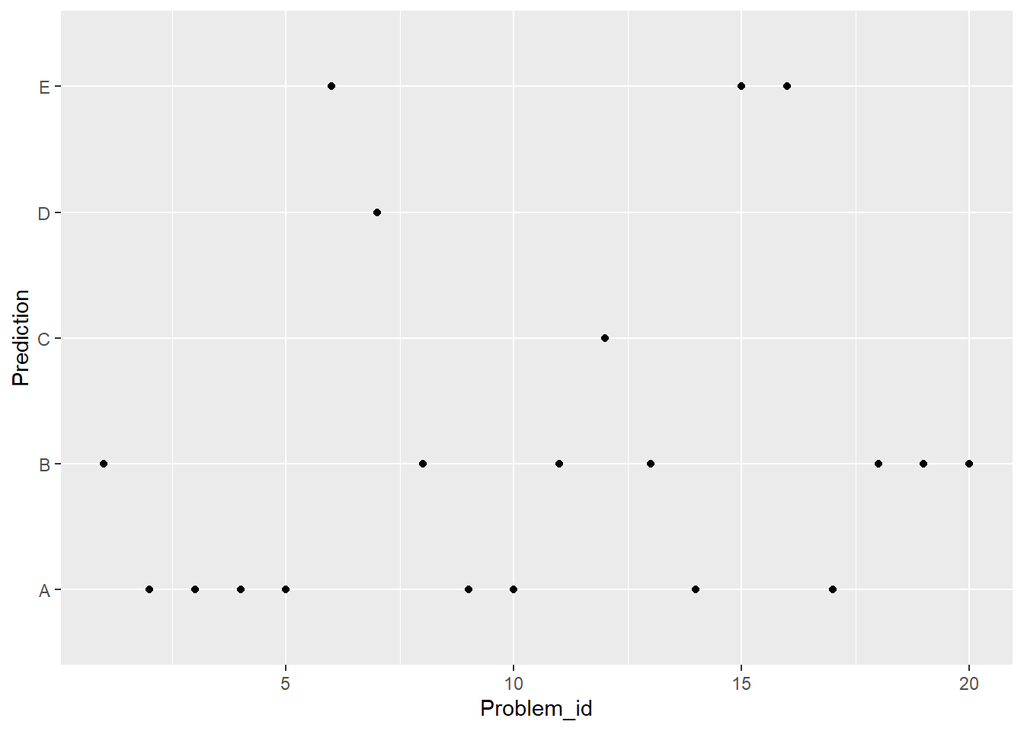

```r
testpca <- predict(pre,testing)
pred1<-predict(fit,testpca)
qplot(testpca$problem_id,pred1,xlab = "Problem_id" ,ylab = "Prediction" )
```